# Day 1: What statistical distribution to pick?

Gentle introduction to statistical distributions: what are they and why are they important

Ben Fanson https://bfanson.github.io/2024DADAworkshop/ (Arthur Rylah Institute)https://www.ari.vic.gov.au/  
2025-09-08

# Collecting data for today

**Note - if online, feel free to grab a fair coin as well as enter your height**

As part of the presentation today, we will use data we collect from simple measurement experiments. We have set up two stations in order to collect some data. The data will be entered into an [online form](https://forms.office.com/Pages/ResponsePage.aspx?id=99a96Bj8SE6lVH9UeSciO_jxmSYRDoFOhTU8JmLuRA5UMlQ4WEcwTk9YT0RFUTBWMkpUVkxKUDFSRS4u)

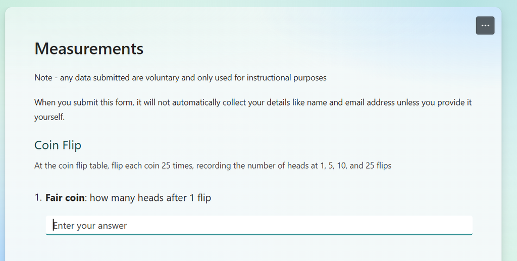

### Station 1: Flipping of coins

There are two coins at the table and you will flip each coin following the steps below (and listed on the online form). One coin has a washer attached (“Weighted”) and a regular (“Fair”) coin.

**Steps:**

1. Select one coin
2. Flip that coin, collecting the number heads you get after 1, 5, 10, and 25 flips.
3. Enter data into form
4. Repeat the same steps for the other coin

[figure not shown]

### Station 2: Measuring “Eel” Wayne and your height

You will measure the height of the cutout of Wayne holding the eel

[figure not shown]

**Steps:**

1. Measure the height of Wayne from the floor to top of head (top of hair)
2. Enter data into online form
3. Enter your height on the form [rough estimate fine]

# Day’s objectives

A REMINDER TO START RECORDING

- Understand what are statistical probability distributions
- Learn some common distributions in ecology and be able to describe their key parameters
- Learn what are observation vs state processes and how it fits into statistical models

# Key packages used today

[figure not shown]

[figure not shown]

# Housekeeping

[Course overview on website](https://bfanson.github.io/2025_Models_workshop/course_overview.html)

# Introduction to statistical distributions

## Example: Measuring fish

*Scenario:* Measuring the length of fish at a fishway

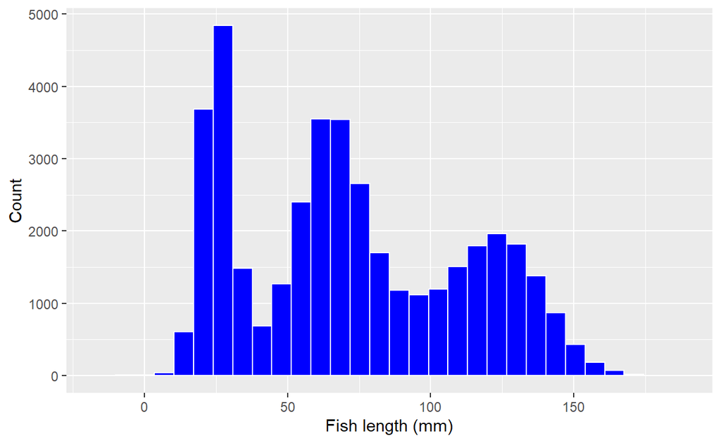

Break up by species…

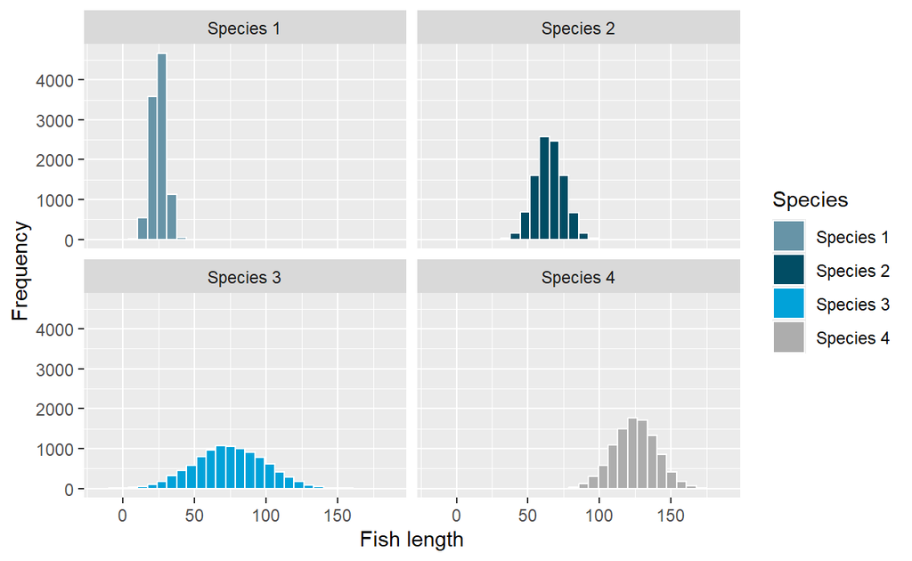

## There are lots of them…

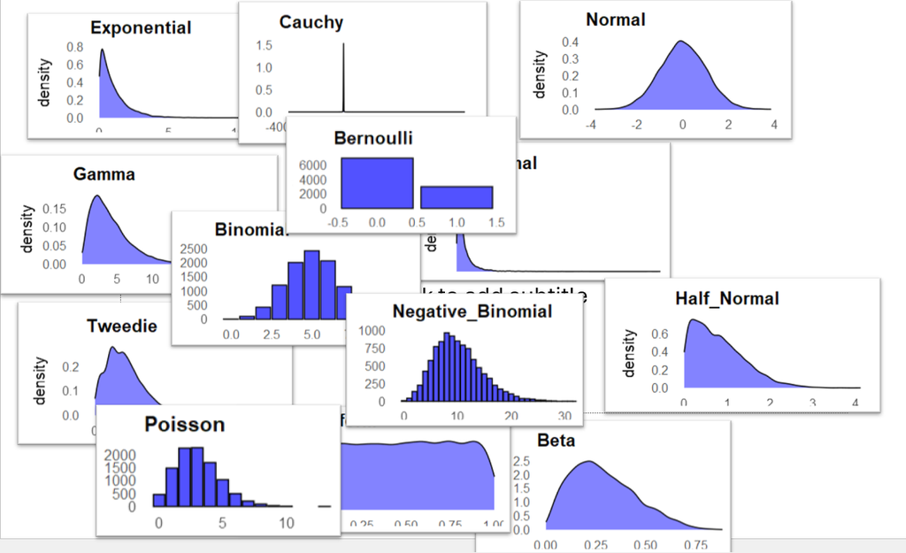

Well over 100 named distributions

## What creates distribution in our data???

1. measurement error
   - limits of measurement tools (accuracy, user-error)
   - miscounting number of birds in large aggregations
   - data entry/workflow errors
2. result of a stochastic process [e.g. probabilistic events like coin toss, survival rates]

**coin toss experiment**

let’s take a look at the data…

```r
  ggplot(ds_coin %>% filter(n_total==25), aes(n_success) ) + geom_histogram(col='white') +
    facet_wrap(~trt) + labs(x='No. of successes')
```

[output not shown]

**animal spacing**

Let’s walk through the classical ecology course on animal spacing…

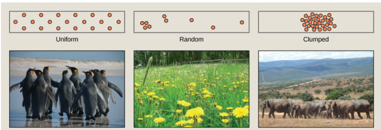

from https://bio.libretexts.org/Bookshelves/Introductory_and_General_Biology

**Scenario:** Imagine we setup a sampling transect of 100 grid that we search for the presence of bird. There are 200 birds that distribute themselves among the 100 grids, differing in degree of spacing from uniform to random to modest clumping.

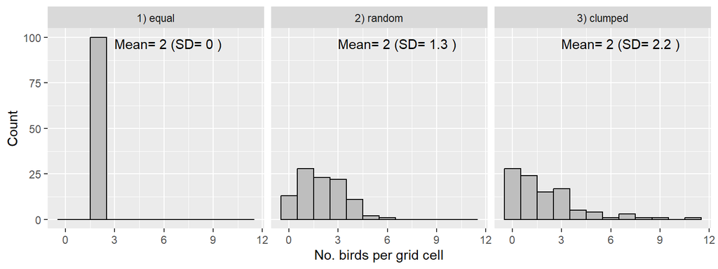

```r
# simulate classical spacing of animals
  n_grids <- 100
  n_birds <- 200

  set.seed(12)
  p <- rbeta(n_grids,1,6) # preferences of grids for clumped
  ds_all <- tibble( grid_id=1:n_grids,
                    `1) equal`=rep( round(n_birds/n_grids), n_grids) ,
                    `2) random`= rmultinom(1, n_birds, prob=rep( 1/n_grids,n_grids) ),
                    `3) clumped` = rmultinom(1,n_birds, prob=p/sum(p) ) ) %>%
            pivot_longer( cols=-grid_id, names_to='type', values_to='n' )

#--- visualise the results ---#
 ds_stat <- group_by(ds_all, type) %>% summarise( mean=round( mean(n) ), sd= round(sd(n),1) )

 ggplot(ds_all, aes(n) ) + geom_histogram(binwidth = 1,fill='grey', col='black') + facet_wrap(~type) +
      geom_text(data=ds_stat, aes( x=3, y=Inf, label=paste('Mean=',mean,'(SD=',sd,')') ),
                vjust=2, hjust=0 ) +
        labs( x='No. birds per grid cell', y='Count' )
```

**Example of from height data**

Let’s look at height data…

```r
  ggplot(ds_ht %>% group_by(trt) %>% mutate(height=height-mean(height)),
         aes(trt, height) ) + geom_violin() + labs(x='Source')
```

[output not shown]

## Why care about it?

- **Filtering out signals from the noise**

[figure not shown]

```r
# height data
#  d <- dslabs::heights  # backup data if cannot download from form
  d <- ds_ht %>% filter(trt=='measurement')
  d <- map_df( 3:30, ~ data.frame( mean_ht=mean(d$height[1:.x]),
                                             sample_size = .x,
                                              se = sd(d$height[1:.x])/sqrt(.x)  ) )
  ggplot(d, aes(sample_size, mean_ht, ymin=mean_ht-se, ymax=mean_ht+se ) ) + geom_pointrange()
```

- **Quantifying that noise to understand ecological processes**

Random effects of height for quantitative genetics [e.g. hints about stabilising selection, gene-environment interactions]

e.g. “male vulnerability hypothesis” to try to explain differing variation between human sexes

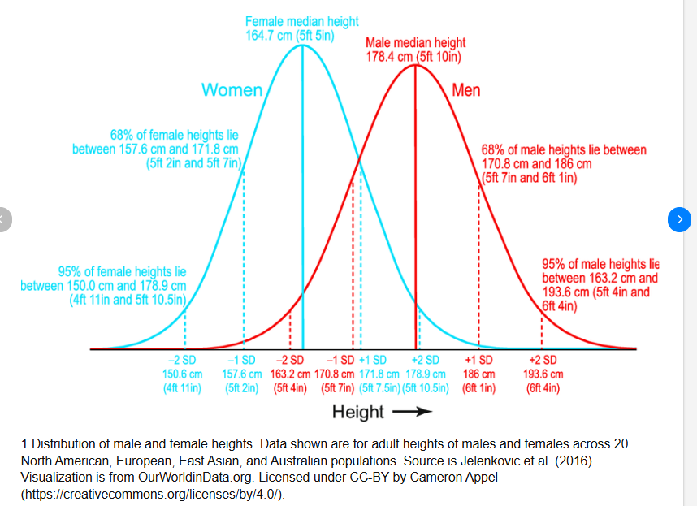

Types of selection

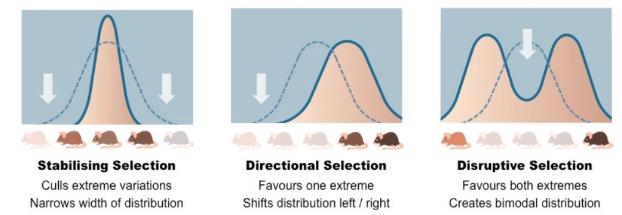

- **Bayesian statistics relies very heavily on**

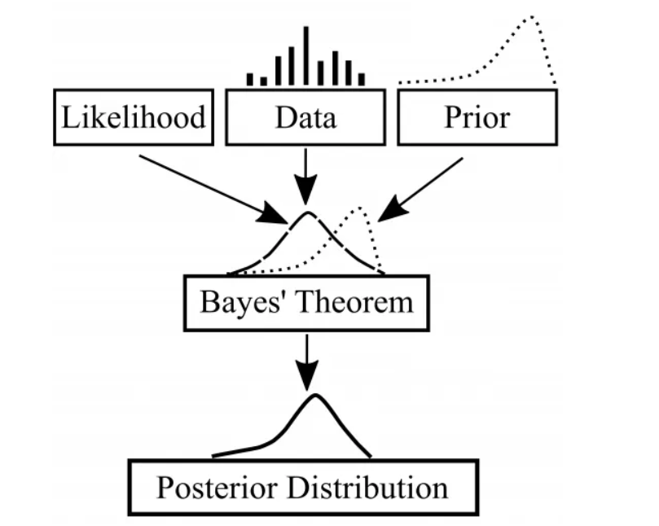

from https://numustafa.medium.com/

- **Making predictions with estimates of uncertainty**

Take a look at normal in the [Shiny App](https://arisci.shinyapps.io/DistributionsBiometrics/)

## Key properties statistical probability distribution

### Type: continuous vs discrete

A *continuous distribution* in statistics refers to a probability distribution in which the random variable can take any value within a given range, often an interval on the real number line.

A *discrete distribution* is a type of probability distribution that describes the likelihood of outcomes for a discrete random variable — one that can take on countable values, often integers or categories.

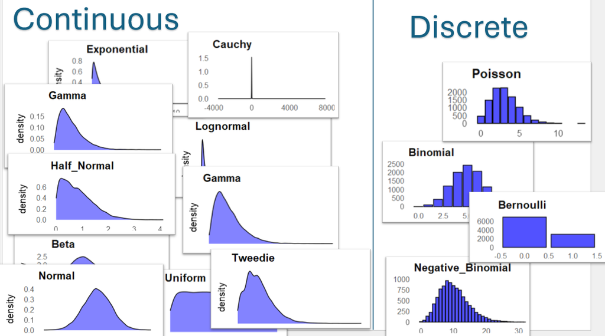

### Location: means and median

**Mean:** $\mu = \frac{1}{n} \sum_{i=1}^{n} x_i$ [average value]

**Median:** the 50th percentile value (middle value)… for {1,2,3,4,5}, median=3

*Bonus: what is the mode?*

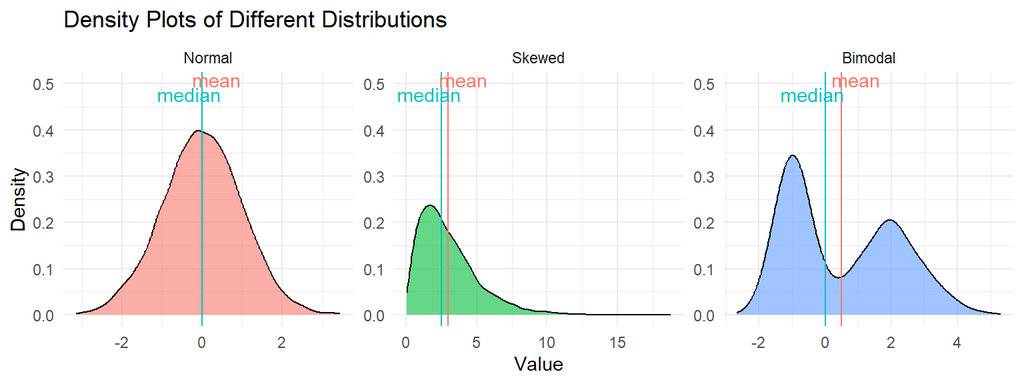

### Spread/dispersion: variance/standard deviation

SD = $\sqrt{\frac{1}{n - 1} \sum_{i=1}^{n} (x_i - \bar{x})^2}$

In essence, average difference from mean penalised by magnitude of the difference (squared cost). Outliers carry much more weight

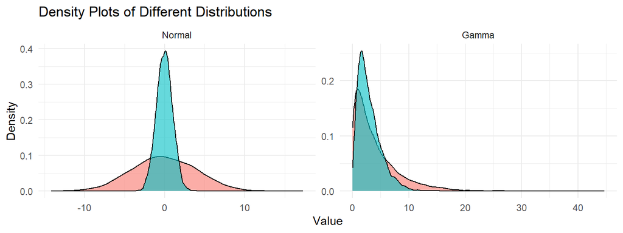

### Support and Shape

Support is the range possible values… e.g. Beta distribution can only range from (0 to 1)

Shape is exactly that, the shape of the curve. Types may be symmetric, skewed, unimodel/bimodal

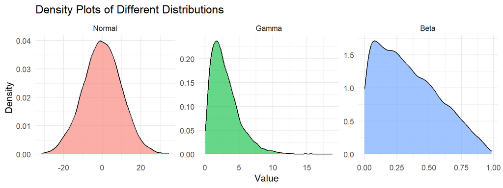

## Tools for visualising distributions using R

### Histograms

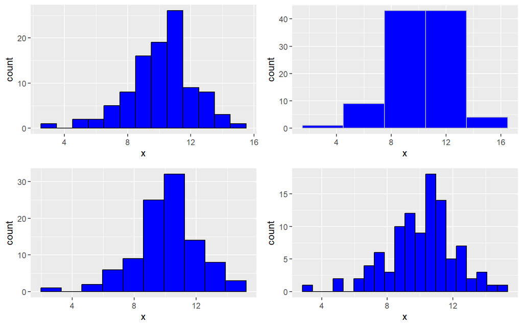

```r
# histograms
  ds <- data.frame( x=rnorm(100, mean=10, sd=2 )  )
  cowplot::plot_grid(
    ggplot( ds, aes(x) ) + geom_histogram( binwidth=1, fill='blue',col='black'),
    ggplot( ds, aes(x) ) + geom_histogram( binwidth=3, fill='blue',col='grey'),
    ggplot( ds, aes(x) ) + geom_histogram( bins=10, fill='blue',col='black'),
    ggplot( ds, aes(x) ) + geom_histogram( bins=20, fill='blue',col='black'),
    nrow=2
  )
```

### Density

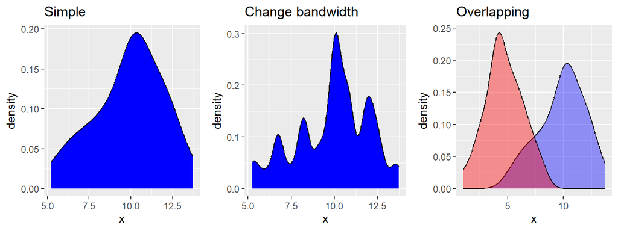

```r
  ds <- data.frame( x=rnorm(50, mean=10, sd=2 ), x2= rnorm(50, mean=5, sd=2 )  )
  cowplot::plot_grid(
    ggplot( ds, aes(x) ) + geom_density( fill='blue', col='black') + labs(title='Simple'),
    ggplot( ds, aes(x) ) + geom_density( fill='blue', col='black',  bw=0.3)+ labs(title='Change bandwidth'),
    ggplot( ds ) +
        geom_density( aes(x), alpha=0.4, fill='blue', col='black') +
        geom_density( aes(x=x2), alpha=0.4, fill='red', col='black') + labs(title='Overlapping'),
    nrow=1
  )
```

### Density

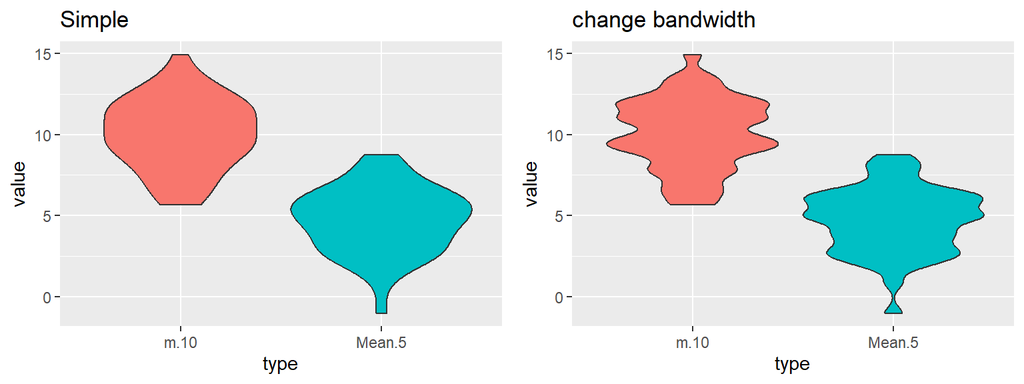

```r
  ds <- data.frame( 'm=10'=rnorm(50, mean=10, sd=2 ),
                     'Mean=5'= rnorm(50, mean=5, sd=2 )  ) %>%
          mutate( id=1:n() ) %>%
          pivot_longer( cols=-id, names_to='type',values_to='value' )
  cowplot::plot_grid(
    ggplot( ds, aes(type, value, fill=type) ) + geom_violin( show.legend = F) +
      labs(title='Simple'),
    ggplot( ds, aes(type, value, fill=type) ) + geom_violin( bw=0.4,show.legend = F ) +
      labs(title='change bandwidth'),
    nrow=1
  )
```

### QQplots: to assess fit to specific distribution

Useful for checking if a distribution matches a specific one

Plots values against the quantiles. If straight(ish) line, then support from that distribution. You can add reference line of the theoretical quantile

*geom_qq()* - default is for normal [see code below for example for non-normal] *geom_qq_line()* - plots the reference line if the data are actually that distribution

```r
# make some data
set.seed(10)
  ds <- data.frame( normal=rnorm(100, mean=10, sd=2 ),
                    gamma = rgamma(50, shape=2, scale=1.5 )  )

# get an estimate of parameters for gamma
  (gamma_parms <- MASS::fitdistr(ds$gamma, 'gamma') )
```

```
     shape         rate
  2.08253136   0.60207926
 (0.27420263) (0.08958277)
```

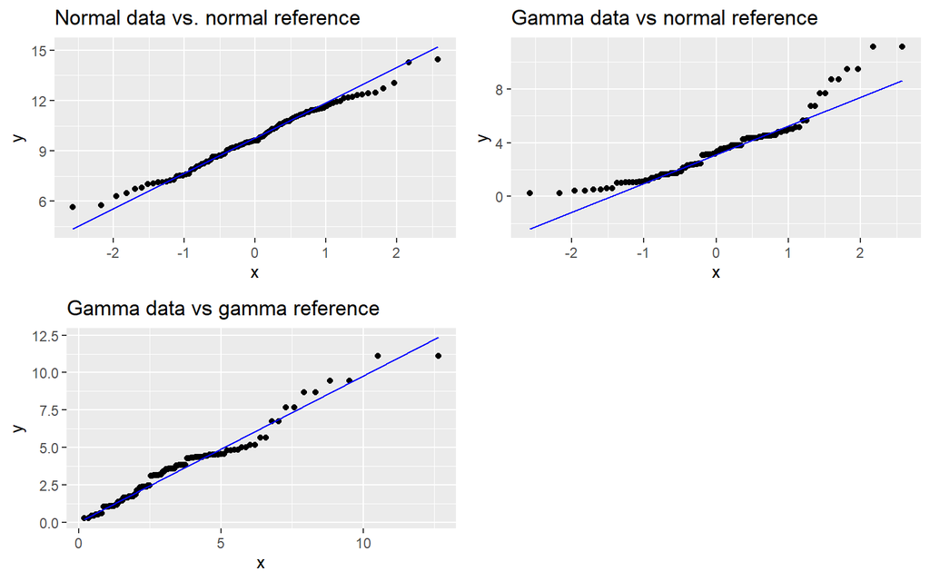

```r
# plot out qqplot
  cowplot::plot_grid(
    ggplot(ds, aes(sample=normal)) + geom_qq() + geom_qq_line(col='blue') +
        labs(title='Normal data vs. normal reference'),
    ggplot(ds, aes(sample=gamma)) + geom_qq() + geom_qq_line(col='blue') +
        labs(title='Gamma data vs normal reference'),
    ggplot(ds, aes(sample=gamma)) +
            geom_qq(distribution = stats::qgamma,
                    dparams=list(shape=2.08, rate=0.60) ) +
            geom_qq_line(col='blue',
                         distribution =stats::qgamma,
                         dparams=list(shape=2.08, rate=0.60) ) +
        labs(title='Gamma data vs gamma reference'),
    nrow=2
  )
```

# Continuous distributions

**Note - we will talk more about on Day 2**

## Normal (aka Gaussian)

Normal is also called the Gaussian after Carl Friedrich Gauss, late 1700s statistician that laid the framework of the normal distribution and foundation for the development of the Central Limit Theorem

### Rationale behind Normal

- empiricist/realist perspective view of the world where measurement imperfections are inevitable but statistically predictable. Errors are random and symmetric and small errors are more likely than large ones

### Key Parameters for location and variance

**Location:** Mean $\mu$ **Variance:** $\sigma^2$

$$y \sim \text{Normal}(\mu, \sigma)$$
[Wikipedia Normal](https://en.wikipedia.org/wiki/Normal_distribution)

*click on image*

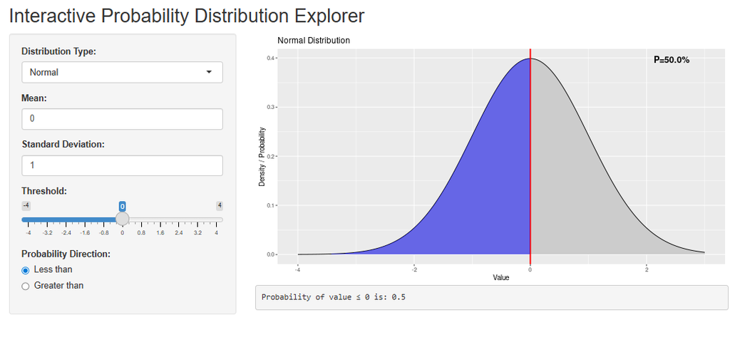

### Summary Table

| Distribution | Type | No. parameters | Parameters | Boundary | Rfunction |
| --- | --- | --- | --- | --- | --- |
| Gaussian | Continuous | 2 | Mean (μ) Standard deviation (σ) | (-Inf, Inf) | rnorm |

### Why so important in statistics?

- the maths for the normal were tractable and had easy, closed solutions
- something called the Central Limit Theorem which states that with large sample sizes, sampling mean converge to a normal distribution

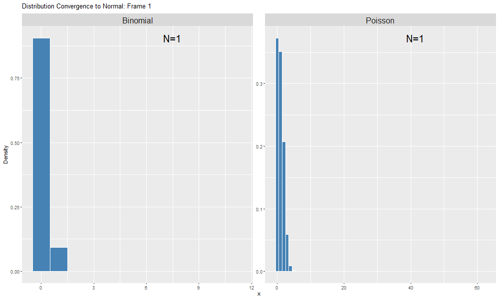

## Log-normal

### Rationale behind log normal

- processes are multiplicative rather than additive
- ecological examples: populate growth rate [ $N(t) = N_0 \cdot \lambda^t$], concentration = [ $Amount = Volume \cdot concentration$] body mass = again dealing with volume [allometry]

### Key parameters for location and spread/variance

**Location:** $\mu$ **Variance:** $\sigma^2$

$$y \sim \text{LogNormal}(\mu, \sigma)$$
[Wikipedia LogNormal](https://en.wikipedia.org/wiki/Log-normal_distribution)

*click on image*

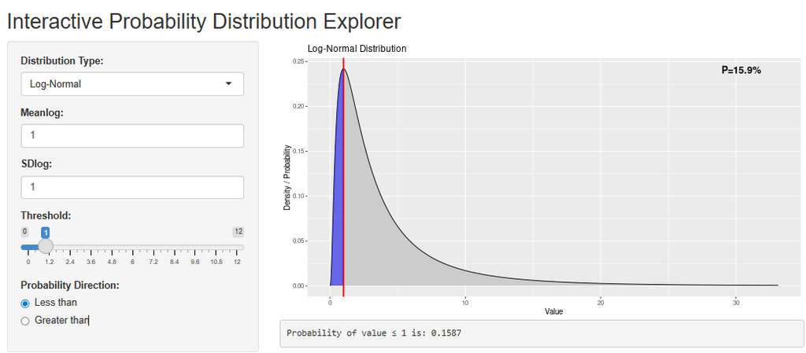

### Summary Table

| Distribution | Type | No. parameters | Parameters | Boundary | Rfunction |
| --- | --- | --- | --- | --- | --- |
| Gaussian | Continuous | 2 | Mean (μ) Standard deviation (σ) | (-Inf, Inf) | rnorm |
| Log-normal | Continuous | 2 | Mean (μ) Standard deviation (σ) | (0,Inf) | rlnorm |

### log(Y) vs Lognormal

You probably have learned about log-transforming Y to do the following: 1) stabilize variance 2) normalise the data 3) linearise relationships

When working with log(y), all predictions are in logs.

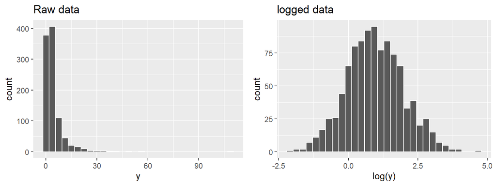

```
    meanlog       sdlog
  1.03800665   0.99490672
 (0.03146171) (0.02224679)
```

```
      mean          sd
  1.03800665   0.99490672
 (0.03146171) (0.02224679)
```

## Beta distribution

### Rationale behind beta distribution

- Beta distribution derived several ways, all pretty mathematical (e.g. conjugate prior, order statistics (kth smallest from n uniform(0,1) samples) )
- The Beta distibution is mainly phenomenological/convenience distribution in ecology.

### Key parameters for Beta and location/variance

The main parameters for Beta are shape parameters… *shape1(/alpha)*: think as number of successes *shape2(/beta)*: think as number of failures

This shape parameters can be combined to define location and variance

**Location:** $\mu = \frac{\alpha}{\alpha + \beta}$ **Variance:** $\sigma^2 = \frac{\alpha \beta}{(\alpha + \beta)^2 (\alpha + \beta + 1)}$

Note - range of values (0,1)

$$y \sim \text{Beta}(\alpha, \beta)$$

*click on image*

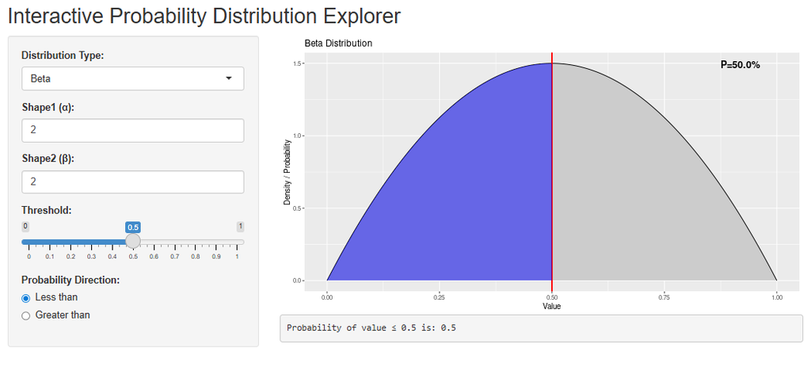

### Summary Table

| Distribution | Type | No. parameters | Parameters | Boundary | Rfunction |
| --- | --- | --- | --- | --- | --- |
| Gaussian | Continuous | 2 | Mean (μ) Standard deviation (σ) | (-Inf, Inf) | rnorm |
| Log-normal | Continuous | 2 | Mean (μ) Standard deviation (σ) | (0,Inf) | rlnorm |
| Beta | Continuous | 2 | Shape parameters α (shape1) β (shape2) | (0,1)} | rbeta |

# Discrete distributions

**Note - we will talk more about on Day 3**

## Binomial(/Bernoulli)

### Rationale behind binomial

- derived from probabilistic/theoretically derived
- in ecology, the distribution fits many scenarios like survival rates, presence/absence

*Note: the Bernoulli distribution is a special case of Binomial in which only one sampling event occurs*

### Key parameters for binomial

p- probability an event N- number of trials (e.g. number of animals tested)

Location: $\mu = N*p$ Variance: $\sigma^2 = N * p * (1 - p)$

*Note - variance increases as p nears 0.5*

$$y \sim \text{Binomial}(p, N)$$

*click on image*

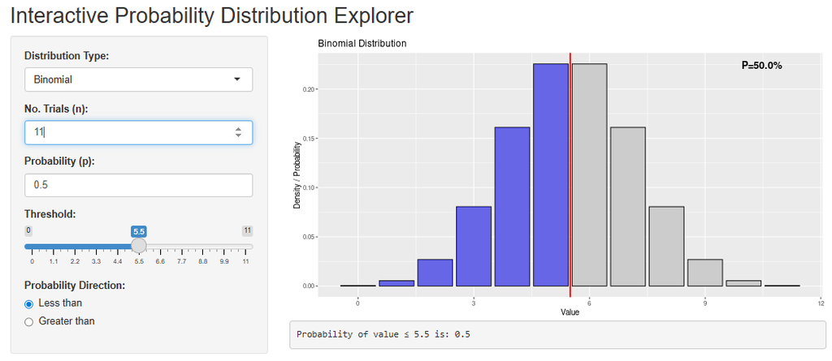

### Summary Table

| Distribution | Type | No. parameters | Parameters | Boundary | Rfunction |
| --- | --- | --- | --- | --- | --- |
| Gaussian | Continuous | 2 | Mean (μ) Standard deviation (σ) | (-Inf, Inf) | rnorm |
| Log-normal | Continuous | 2 | Mean (μ) Standard deviation (σ) | (0,Inf) | rlnorm |
| Beta | Continuous | 2 | Shape parameters α (shape1) β (shape2) | (0,1)} | rbeta |
| Binomial | Discrete | 2 | Number of trials (n) Probability of success (p) | [0,1,2,...,n] | rbinom |

## Poisson

### Rationale behind Poisson

- derived from probabilistic/theoretically derived.
- Poisson is about **the rate** an event happens (e.g.number times/hour)
- in ecology, the distribution fits many scenarios, often do to sampling design and measuring rates. For instance, number of individuals per sampling area (N/area), number of fish through fishway per hour (n/hr), number of plant stems touching a stick (n/stick)

### Key parameters for Poisson

$\lambda$- rate that an event happens

Location: $\mu=\lambda$ Variance: $\sigma^2 = \lambda$

*Note - variance increases as the rate*

$$y \sim \text{Poisson}(\lambda)$$

*click on image*

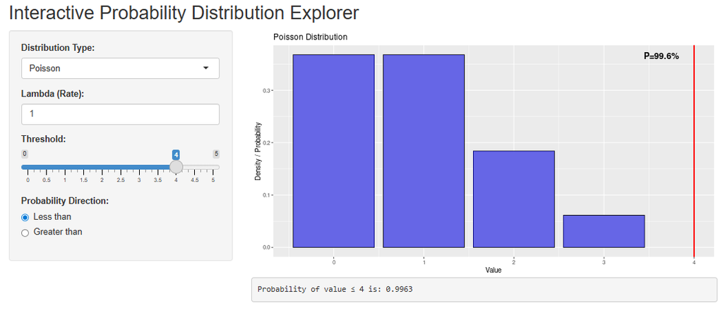

### Summary Table

[output not shown]

## Negative Binomial

### Rationale behind Negative Binomial

- derived from probabilistic/theoretically derived [from gambling, wanting to know how many trials are needed to achieve a certain number of successes]
- another approach was allowing Poisson distribution $\lambda$ to vary (as Gamma distribution). This is closer to our use in ecology
- I would argue more of a convenience distribution in ecology
- Negative binomial is used lots as often Poisson underestimates variability. E.g. not every plot is equally attractive to an animal (animal spacing problem)

Lot of the early thinking about probabilities and stochastic events originated in the gambling/games of change world although back to 1500s. This tradition has extended to the present day

### Key parameters for negative binomial

Location: $\mu$ Variance/dispersion: size ($\theta$) [ decreasing size = higher overdispersion ]

$$y \sim \text{NegativeBinomial}(\mu, \theta)$$

*click on image*

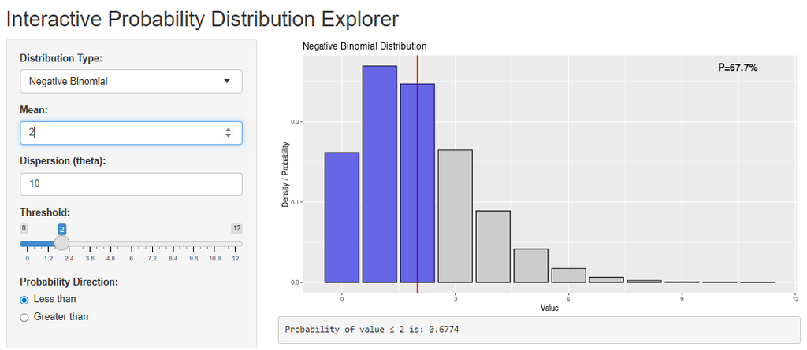

# Mixture distributions

You can combine distributions

**Note - we will talk more about on Day 4**

## Zero-inflated Poisson

### Rationale behind

*Scenario:* Surveying wetland sites to count the number of frogs from rare species

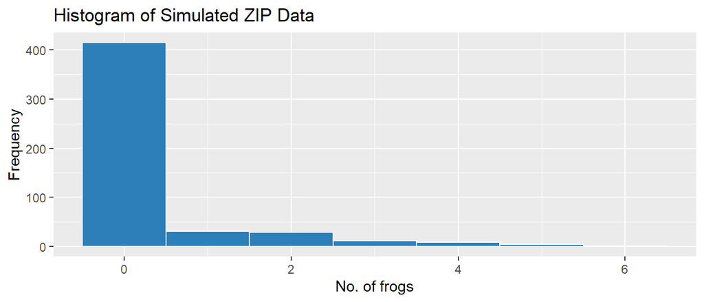

```r
    n_wetland=100
    n_grid = 5
    p= 0.8  # 80% empty
    lambda = 2 # 2/grid
    set.seed(123)
    is_zero <- rbinom(n_wetland, 1, p)
    y <- map( 1:n_wetland, ~if(is_zero[.x] == 1){rep(0,n_grid)}else{rpois(n_grid, lambda)} ) %>% flatten() %>% unlist()

    ggplot( tibble(value = y), aes(x = y)) +
      geom_histogram(binwidth = 1, fill = "#2c7fb8", color = "white") +
      labs(title = "Histogram of Simulated ZIP Data",
           x = "No. of frogs", y = "Frequency")
```

**Cause of the excess zeros**

1. **Structural zeros:** Sites where frogs are truly absent (e.g., no water, wrong vegetation).
2. **Sampling zeros:** Sites where frogs are present but not detected during the survey.

### Key parameters for binomial

p- probability for binomial component (e.g. frogs present at the wetland) $\lambda$ - rate (e.g. if frogs present, density of frogs)

Location: $\mu = (1-p)*\lambda$ Variance: $\sigma^2 = (1 - p)*\lambda*(1+p*\lambda)$

$$y \sim \text{ZIP}(p, \lambda)$$

# Observation vs Process framework

### Let’s build up an example…

```r
# grab the data
  library(dslabs)  # package with the dataset
  data(heights)
  ds_hts <- heights
  head(ds_hts)
```

```
     sex height
1   Male     75
2   Male     70
3   Male     68
4   Male     74
5   Male     61
6 Female     65
```

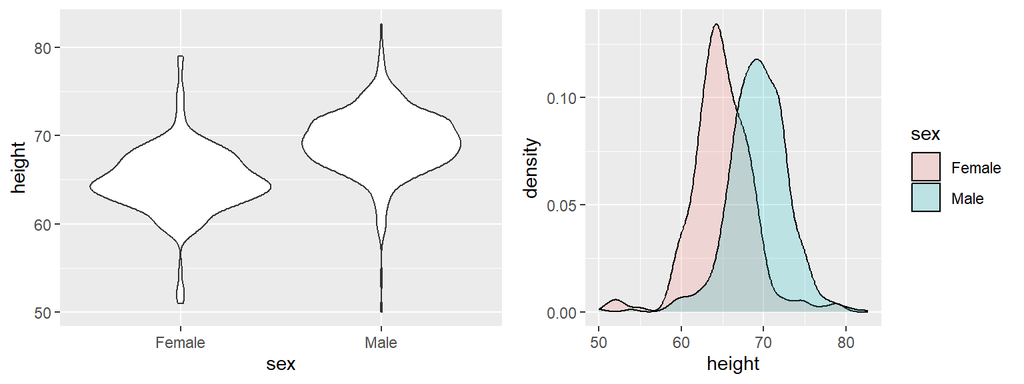

```r
# visualise the data
  cowplot::plot_grid(
    ggplot(ds_hts, aes(sex, height) ) + geom_violin(),
    ggplot(ds_hts, aes( height, fill=sex) ) + geom_density( alpha=0.2 ),
    nrow=1
  )
```

```r
# get key parameters
  ds_stat <- group_by(ds_hts, sex) %>%
    summarise( ht_mean = mean(height), sd_ht = sd(height)) %>%
    ungroup() %>%
    mutate(diff_mean = diff(ht_mean))
```

#### Equation

$$height_{male} \sim \text{Normal}(\mu_{male}, \sigma_{male})$$
$$height_{female} \sim \text{Normal}(\mu_{female}, \sigma_{female})$$
Let’s assume males and females have the same variation: $\sigma_{female}$ = $\sigma_{male} = \sigma$

$$height_{male} \sim \text{Normal}(\mu_{male}, \sigma)$$
$$height_{female} \sim \text{Normal}(\mu_{female}, \sigma)$$

Okay, let’s now simplify more

$$y_i \sim \text{Normal}(\mu_i, \sigma)$$
where i = male or female and $y_i = height_i$

$$\mu_i = sex$$

#### Observation component (distribution)

$$y_i \sim \text{Normal}(\mu_i, \sigma)$$

#### Process component

$$\mu_i = sex$$

More accurately…
$$p_i = Intercept + Male*X$$

#### the R formula

```r
  glm( height ~ sex, data=ds_hts, family=gaussian )
```

### Example with the coins

#### Observation component (distribution)

$$y_i \sim \text{Binomial}(p_i, N)$$

where i = fair or weighted and $y_i = n_{successes}$

#### Process component

$$p_i = \text{coin_type}$$

More accurately…
$$p_i = Intercept + Weighted * X$$

#### the R formula

```r
  ds_coin <- rename(ds_coin, coin_type=trt) %>%
              mutate(n_failures= n_total-n_success)
  glm( cbind(n_success, n_failures) ~ coin_type, data=ds_coin, family=binomial )
```

**Bonus question: what do random effects (such are a statistical distribution) come into the observation-process model formulation???**